# Assignment 4

Import the matplotlib and numpy packages

```python
import numpy as np
import matplotlib.pyplot as plt
```

### a) For-loops and Conditional Statements

Using the lists of movie ratings and titles below, where each rating corresponds directly to the title in the same position,  
create a new list of movies that are considered top picks (**those with ratings greater than or equal to 8**):

- Use a for loop to iterate through both lists below and store the titles and ratings of movies  
  considered top picks in two new lists:
  - `top_picks_titles`: The titles of movies considered top picks.
  - `top_picks_ratings`: The ratings of top pick movies.
- Print the results of both lists.

```python
# run this cell first
movie_ratings = [6.8, 8.3, 8.5, 5.1, 8.0, 3.5, 7.8, 8.4, 7.8, 2.8, 8.8]
movie_titles = ["Barbie", "Oppenheimer", "Spider-Man: Across the Spider-Verse",
                "Morbius", "Dune", "The Emoji Movie",
                "Everything Everywhere All at Once", "Avengers: Endgame",
                "The Batman", "Cats", "Pulp Fiction"]
```

```python
#Creates two empty list for me to store the movies that are the above a rating of 8, like how I'm doing in QTM 150
top_picks_titles = []
top_picks_ratings = []

# I use a for loop to check if they pass the 8 threshold, then I'll add (append) them to the new list, just like I do in QTM 150
for movie in range(len(movie_titles)): #for each movie in the movie_titles list (range(len()) gives the like the position we are in the list)
    if movie_ratings[movie] >= 8:  #checks if the movie_ratings at that position is greather than or equal to 8
        top_picks_titles.append(movie_titles[movie]) #Adds the title of the movie at that position to the top_picks_titles list
        top_picks_ratings.append(movie_ratings[movie]) #Same as above but for ratings

print(top_picks_titles)
print(top_picks_ratings)
```

```
['Oppenheimer', 'Spider-Man: Across the Spider-Verse', 'Dune', 'Avengers: Endgame', 'Pulp Fiction']
[8.3, 8.5, 8.0, 8.4, 8.8]
```

### b) Follow-up to Part (a)

Using numpy, perform the following operations on the `top_picks_ratings` list:

- Count and print the total number of movies considered top picks using `np.size()`.
- Calculate and print the average ratings of the top pick movies using `np.mean()`.
- Determine and print the highest rating from the top pick movies using `np.max()`.

**You should assign each computed value to a variable**

Hint: Most numpy operations work with lists, not just arrays

```python
import numpy as np

number_of_top_picks = np.size(top_picks_ratings)
average_ratings_of_top_picks = np.mean(top_picks_ratings)
highest_rated_movie = np.max(top_picks_ratings)

print(number_of_top_picks)
print(average_ratings_of_top_picks)
print(highest_rated_movie)
```

```
5
8.4
8.8
```

### c) For-loops + Plotting

- Create an array of x-values with 100 evenly spaced points between $0$ and $2\pi$  
  using `np.linspace()`. **Hint**: type `help(np.linspace)` in a separate cell to see how it is used
- Create a vector named `vec_y1` where each element is computed from the formula  
  $ y_k = \sin(x_k)$. (Here $x_k$ is the $k$-th element of the array you created above, and $y_k$ is the $k$-th element of vec_y1)
- Create a vector `vec_y2` where each element is computed from the formula  
  $ y_k = \cos(x_k)$.
- Create a list `list_vectors` with elements `vec_y1` and `vec_y2`. (So a list with two components, both being numpy arrays)
- Create a for-loop that goes through each element of `list_vectors` and plots each  
  list of $y$ values on the vertical axis against $x$ on the horizontal axis.

Note: The final output should be a 2-dimensional plot with the values from vec_y1 and vec_y2 on the vertical axis, and the $x$ values on the horizontal axis. **Remember to label the axes and add a title to the plot**.

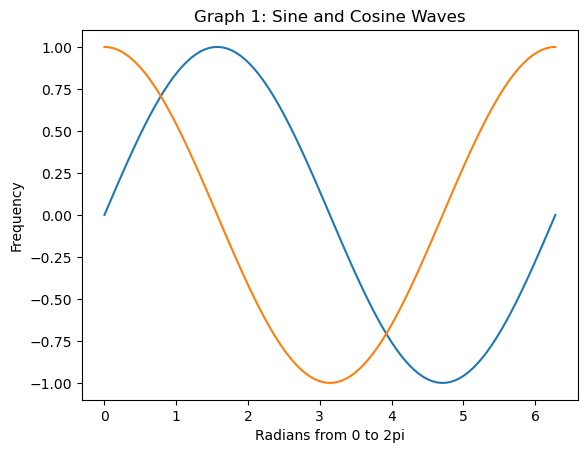

```python
x_values = np.linspace(0, 2*np.pi, 100)
vec_y1 = np.sin(x_values)
vec_y2 = np.cos(x_values)
list_vectors = [vec_y1, vec_y2]

for vec in list_vectors:
    plt.plot(x_values, vec)

plt.title("Graph 1: Sine and Cosine Waves")
plt.xlabel("Radians from 0 to 2pi")
plt.ylabel("Frequency")
plt.show()

#Note for me, I accidently was writing everything after plt.show which was making 2 graphs and i was confused
#I tried including plt.show() in the for loop which also made 3 graphs, so I moved it outside the for loop
```

```python
help(np.linspace) #The first part of help is the minimum, then the 2nd argument is the maximum, and the 3rd agument is the maximum
```

[output not shown]

[output cut: 53 more lines]

[output not shown]

### d) Learn How to Use zip()

- Below, write a chunk of code that prints out the average score for each player over the 3 rounds.  
  The names and scores are given in the lists below.
- The program should print the players's name and their average score, formatted like this:

  ```
  John's average score: ___
  Bob's average score: ___
  Jane's average score: ___
  Dave's average score: ___
  Jenny's average score: ___
  ```

- Use the `zip` function in the heading of the loop. **You should use all four lists in the heading**

Hints/Tips:

- You can learn more about zip() here: [Python zip() Function](https://www.geeksforgeeks.org/zip-in-python/)
- You can print a string followed by a float using print as follows:

```
    print(some_string, some_float)
```

- ...or you can convert the float to a string using `str`

```python
# run this cell first
player_names = ["John", "Bob", "Jane", "Dave", "Jenny"]
round1 = [120, 200, 150, 300, 180]
round2 = [100, 210, 160, 280, 190]
round3 = [130, 190, 170, 310, 175]
```

```python
help(zip) #zip takes in multiple lists and combines them into a list of tuples (What are tuples?)
```

[output not shown]

```python
scores = zip(player_names, round1, round2, round3) #This combines the 4 lists into their respective order
print(list(scores)) #I have to add list() for print or else it just tells me what it is
```

```
[('John', 120, 100, 130), ('Bob', 200, 210, 190), ('Jane', 150, 160, 170), ('Dave', 300, 280, 310), ('Jenny', 180, 190, 175)]
```

### e) Simulating and Visualizing

- We will generate and plot multiple histograms of sample means for the **log-normal** distribution.
- The log-normal distribution arises by raising Euler's number ($\mathrm{e}$) to the power of a number drawn from a normal distribution. This is the *underlying* normal distribution.
- If $\mu$ is the mean of the underlying normal distribution, and $\sigma$ is the standard deviation of the underlying normal distribution, then: $$ \textrm{mean of log-normal distribution } = \mathrm{e}^{\mu + \frac{\sigma^2}{2}} = \exp\left(\mu + \frac{\sigma^2}{2} \right)$$
- For this question, we will use $\mu = 1$ and $\sigma = 0.5$
- Generate and plot multiple histograms showing the frequency of sample means computed with different sample sizes:
  - Create 3 histograms: one with sample size 10, one with sample size 100, and one  
    with sample size 1000.
  - Make sure that the number of simulations is the same for all three (keep the number  
    of simulations set to 2000)
- Using your histograms from the question above, how does the sample size affect the  
  distribution of the sample means? Answer this question in a markdown cell or as a comment in a Python cell.
- **Hint**: you will want to use the function `np.random.lognormal`